# Reproducible Research - Course project 1

Felipe Wolff

2023-04-17

## Library

The packages that will be used:

```r
library(dplyr)
```

```r
library(ggplot2)
library(scales)
```

## Loading and processing the data

```r
activity <- read.csv("activity.csv")

activity$date <- as.Date(activity$date, "%Y-%m-%d")
activity <- tibble::as_tibble(activity)
activity
```

```
## # A tibble: 17,568 × 3
##    steps date       interval
##    <int> <date>        <int>
##  1    NA 2012-10-01        0
##  2    NA 2012-10-01        5
##  3    NA 2012-10-01       10
##  4    NA 2012-10-01       15
##  5    NA 2012-10-01       20
##  6    NA 2012-10-01       25
##  7    NA 2012-10-01       30
##  8    NA 2012-10-01       35
##  9    NA 2012-10-01       40
## 10    NA 2012-10-01       45
## # … with 17,558 more rows
```

```r
str(activity)
```

```
## tibble [17,568 × 3] (S3: tbl_df/tbl/data.frame)
##  $ steps   : int [1:17568] NA NA NA NA NA NA NA NA NA NA ...
##  $ date    : Date[1:17568], format: "2012-10-01" "2012-10-01" ...
##  $ interval: int [1:17568] 0 5 10 15 20 25 30 35 40 45 ...
```

## Q1: What is mean total number of steps taken per day?

- Calculate the total number of steps taken per day the data set had to be cleaned by removing the NA values in each row, this was made by complete cases function.

```r
act_na_rm <- activity[complete.cases(activity),]
act_na_rm <- tibble::as_tibble(act_na_rm)
act_na_rm
```

```
## # A tibble: 15,264 × 3
##    steps date       interval
##    <int> <date>        <int>
##  1     0 2012-10-02        0
##  2     0 2012-10-02        5
##  3     0 2012-10-02       10
##  4     0 2012-10-02       15
##  5     0 2012-10-02       20
##  6     0 2012-10-02       25
##  7     0 2012-10-02       30
##  8     0 2012-10-02       35
##  9     0 2012-10-02       40
## 10     0 2012-10-02       45
## # … with 15,254 more rows
```

- Histogram for total step per day in ggplot2

The histogram takes the base of complete cases

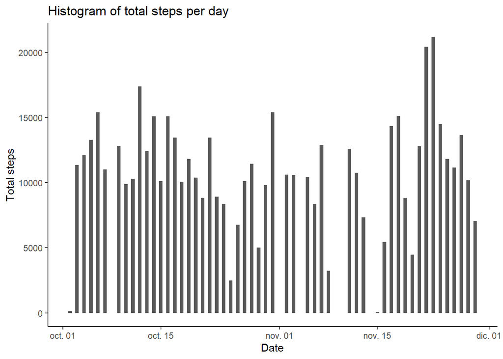

```r
ggplot(act_na_rm, aes(x=date, y=steps)) +
  geom_histogram(stat = "identity", width=0.5) +
        xlab("Date")+ ylab("Total steps")+
        ggtitle("Histogram of total steps per day")+
        theme(plot.title=element_text(hjust=0.5))+
        theme_classic()
```

- Calculate and report the mean and median of the total number of steps taken per day

```r
steps_narm <- mean(activity$steps, na.rm= TRUE)

mean_steps <- mean(steps_narm)
print(mean_steps)
```

```
## [1] 37.3826
```

```r
median_stepsnarm <- median(steps_narm)
print(median_stepsnarm)
```

```
## [1] 37.3826
```

## Q2: What is the average daily activity pattern?

```r
day_mean <- with(na.omit(activity), tapply(steps, interval, mean))
day_max <- day_mean
day_mean <- tibble::as.tibble(day_mean)
dates <- activity %>% group_by(date) %>%
        group_by(interval) %>%
        summarise(meansteps = mean(steps, na.rm=TRUE))
dates
```

```
## # A tibble: 288 × 2
##    interval meansteps
##       <int>     <dbl>
##  1        0    1.72
##  2        5    0.340
##  3       10    0.132
##  4       15    0.151
##  5       20    0.0755
##  6       25    2.09
##  7       30    0.528
##  8       35    0.868
##  9       40    0
## 10       45    1.47
## # … with 278 more rows
```

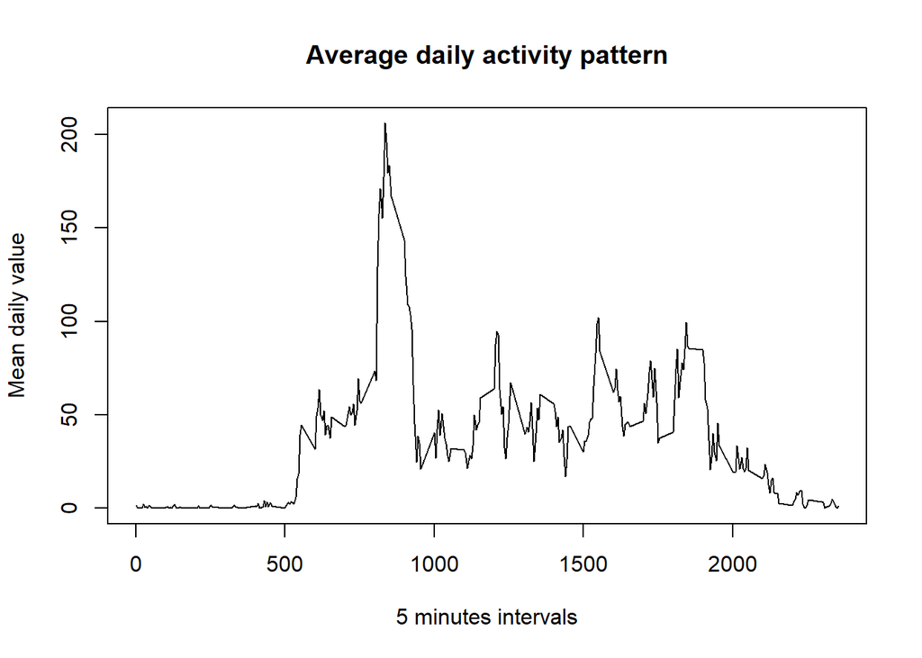

```r
plot(x = dates$interval, y = day_mean$value, type= "l", ylab= "Mean daily value",
     xlab="5 minutes intervals", main = "Average daily activity pattern")
```

Maximum activity record in interval 835, equals to 206.2

```r
day_max[which(day_max == max(day_max))]
```

```
##      835
## 206.1698
```

## Inputing missing values

- Total number of Na in data set

```r
NA_steps <- activity[is.na(activity$steps),]
sum(is.na(NA_steps$steps))
```

```
## [1] 2304
```

- Ratio of NA observations

```r
na_ratio <- sum(is.na(activity$steps))/length(activity$steps)
percent(na_ratio)
```

```
## [1] "13%"
```

Replace the NA’s in original Data frame with the mean of interval-date steps

```r
NA_steps$steps <- replace(NA_steps$steps, dates$interval %in% NA_steps$interval,
                          dates$meansteps)
activity$steps <- replace(activity$steps,
                          activity$interval %in% NA_steps$interval &
                          activity$date %in% NA_steps$date, NA_steps$steps)

head(activity)
```

```
## # A tibble: 6 × 3
##    steps date       interval
##    <dbl> <date>        <int>
## 1 1.72   2012-10-01        0
## 2 0.340  2012-10-01        5
## 3 0.132  2012-10-01       10
## 4 0.151  2012-10-01       15
## 5 0.0755 2012-10-01       20
## 6 2.09   2012-10-01       25
```

```r
tail(activity)
```

```
## # A tibble: 6 × 3
##   steps date       interval
##   <dbl> <date>        <int>
## 1 2.60  2012-11-30     2330
## 2 4.70  2012-11-30     2335
## 3 3.30  2012-11-30     2340
## 4 0.642 2012-11-30     2345
## 5 0.226 2012-11-30     2350
## 6 1.08  2012-11-30     2355
```

- histogram of daily steps

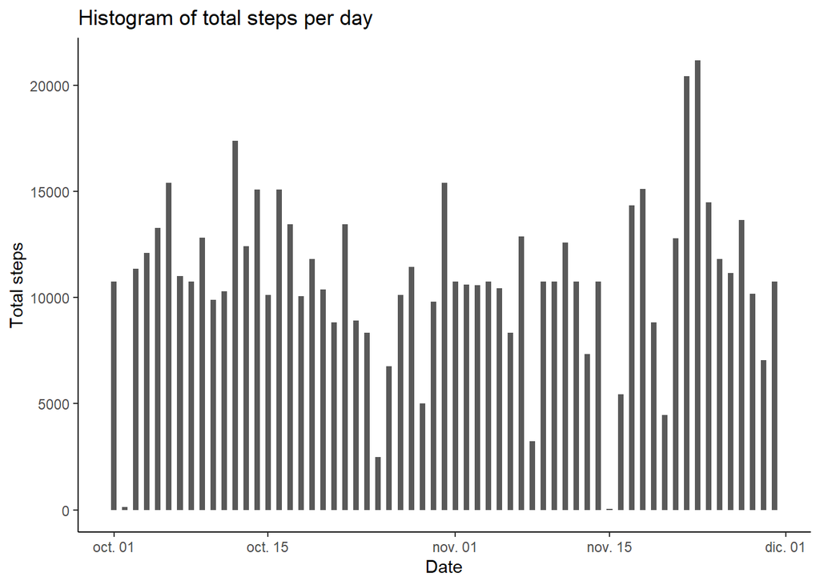

```r
ggplot(activity, aes(x=date, y=steps)) +
  geom_histogram(stat = "identity", width=0.5) +
        xlab("Date")+ ylab("Total steps")+
        ggtitle("Histogram of total steps per day")+
        theme(plot.title=element_text(hjust=0.5))+
        theme_classic()
```

- Mean and median estimates with no NA values in data frame

```r
steps_mean <- mean(activity$steps)
steps_mean
```

```
## [1] 37.3826
```

```r
steps_median <- median(activity$steps)
steps_median
```

```
## [1] 0
```

- what is the impact of impulsing missing data on the estimates of the total daily number of steps?

The mean did not differ form the initial value calculated, but the median value drop off from a value of 37.3826 to 0. Consider the amplitude and the variance of the data frame it seems a very intensive change in the value.

## Are there differences in activity patterns between weekdays and weekends?

```r
activity <- mutate(activity, day = weekdays(activity$date))

dias <- c('lunes', 'martes', 'miércoles', 'jueves', 'viernes')

# grepl function allows to filter from text

activity$day_cl <- ifelse(grepl("es",activity$day), "weekday", "weekend")

unique(activity$day_cl)
```

```
## [1] "weekday" "weekend"
```

then, I create two subsets of the data frame separate the weekdays and the weekend days:

```r
weekday <- activity %>% filter(grepl("day",activity$day_cl))

weekend <- activity %>% filter(grepl("end",activity$day_cl))

weekday
```

```
## # A tibble: 12,960 × 5
##     steps date       interval day   day_cl
##     <dbl> <date>        <int> <chr> <chr>
##  1 1.72   2012-10-01        0 lunes weekday
##  2 0.340  2012-10-01        5 lunes weekday
##  3 0.132  2012-10-01       10 lunes weekday
##  4 0.151  2012-10-01       15 lunes weekday
##  5 0.0755 2012-10-01       20 lunes weekday
##  6 2.09   2012-10-01       25 lunes weekday
##  7 0.528  2012-10-01       30 lunes weekday
##  8 0.868  2012-10-01       35 lunes weekday
##  9 0      2012-10-01       40 lunes weekday
## 10 1.47   2012-10-01       45 lunes weekday
## # … with 12,950 more rows
```

```r
weekend
```

```
## # A tibble: 4,608 × 5
##    steps date       interval day    day_cl
##    <dbl> <date>        <int> <chr>  <chr>
##  1     0 2012-10-06        0 sábado weekend
##  2     0 2012-10-06        5 sábado weekend
##  3     0 2012-10-06       10 sábado weekend
##  4     0 2012-10-06       15 sábado weekend
##  5     0 2012-10-06       20 sábado weekend
##  6     0 2012-10-06       25 sábado weekend
##  7     0 2012-10-06       30 sábado weekend
##  8     0 2012-10-06       35 sábado weekend
##  9     0 2012-10-06       40 sábado weekend
## 10     0 2012-10-06       45 sábado weekend
## # … with 4,598 more rows
```

The data set contains the week split into weekdays and weekend. I also made two new data frames for each variable.

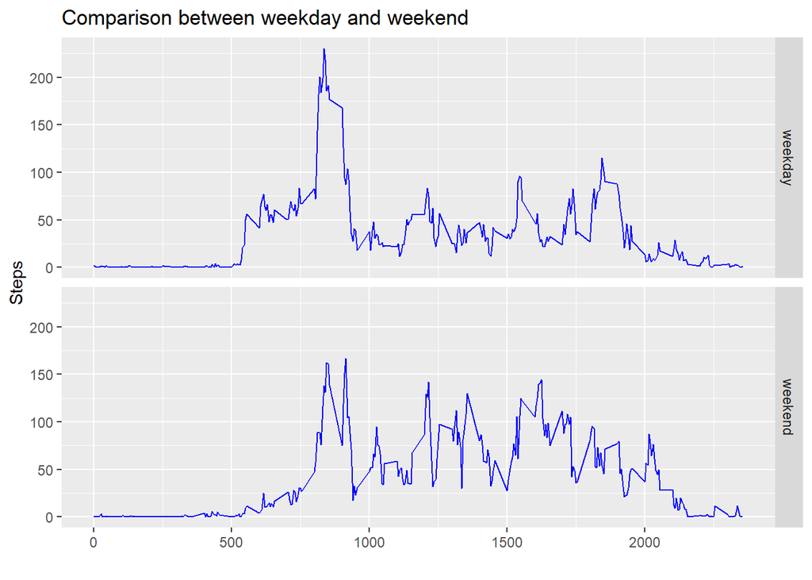

```r
act_week_cl <- aggregate(steps~interval+day_cl, data = activity, mean)

ggplot(data = act_week_cl, aes(x=interval, y=steps)) +
  geom_line(color = "blue", size = 0.5) +
  labs(title = "Comparison between weekday and weekend",
       y = "Steps", x = "") +
  facet_grid(day_cl ~ .)
```